# Nursing Home COVID with Star Rating

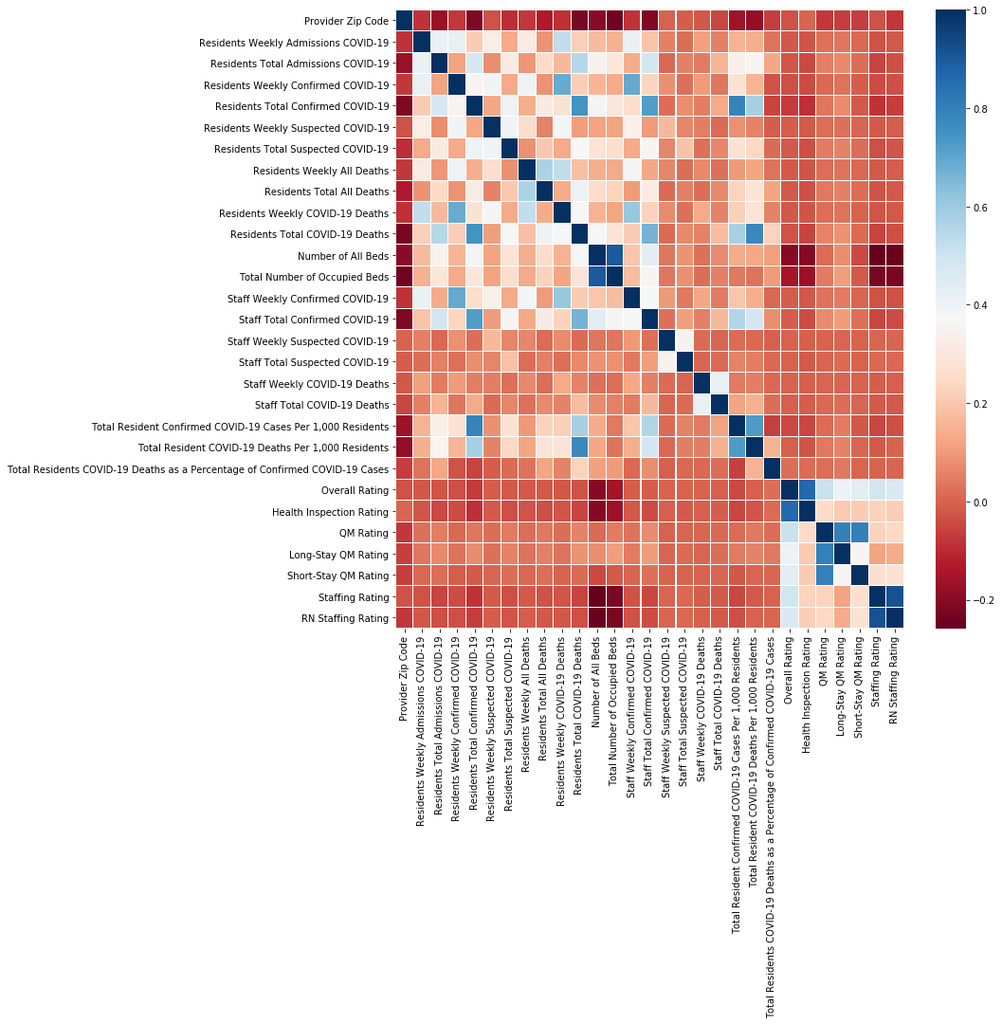

```python
correlation_matrix = filtered_data.corr()
f, ax = plt.subplots(figsize = (12,12))
sns.heatmap(correlation_matrix, ax = ax, cmap ="RdBu",linewidths = 0.1)
```

```python
filtered_data=filtered_data[filtered_data['Submitted Data']=='Y']
```

The below table denotes the Total Confirmed COVID-19 cases in United States

```python
x=filtered_data.groupby('Provider State_x',sort=True)['Residents Total Confirmed COVID-19'].sum()
df = pd.DataFrame(x).reset_index()
df.columns = ['State', 'Total Confirmed COVID-19 cases']
df
```

|  | State | Total Confirmed COVID-19 cases |
| --- | --- | --- |
| 0 | AL | 53.0 |
| 1 | AR | 155.0 |
| 2 | CA | 31730.0 |
| 3 | CO | 2.0 |
| 4 | DE | 288.0 |
| 5 | FL | 31263.0 |
| 6 | GA | 33520.0 |
| 7 | GU | 0.0 |
| 8 | HI | 67.0 |
| 9 | IA | 8998.0 |
| 10 | ID | 634.0 |
| 11 | IL | 74322.0 |
| 12 | IN | 25864.0 |
| 13 | KS | 2544.0 |
| 14 | KY | 12074.0 |
| 15 | LA | 31453.0 |
| 16 | MA | 82548.0 |
| 17 | MD | 35875.0 |
| 18 | ME | 1463.0 |
| 19 | MI | 29406.0 |
| 20 | MN | 13798.0 |
| 21 | MO | 14035.0 |
| 22 | MS | 13774.0 |
| 23 | MT | 51.0 |
| 24 | NC | 17861.0 |
| 25 | ND | 1086.0 |
| 26 | NE | 3162.0 |
| 27 | NH | 7176.0 |
| 28 | NJ | 100891.0 |
| 29 | NM | 2280.0 |
| 30 | NV | 5085.0 |
| 31 | NY | 95799.0 |
| 32 | OH | 35186.0 |
| 33 | OK | 4852.0 |
| 34 | OR | 1141.0 |
| 35 | PA | 83430.0 |
| 36 | PR | 1.0 |
| 37 | RI | 14745.0 |
| 38 | SC | 13020.0 |
| 39 | SD | 543.0 |
| 40 | TN | 5461.0 |
| 41 | TX | 39802.0 |
| 42 | UT | 1844.0 |
| 43 | VA | 17591.0 |
| 44 | VT | 888.0 |
| 45 | WA | 8253.0 |
| 46 | WI | 6989.0 |
| 47 | WV | 2131.0 |
| 48 | WY | 139.0 |

The below bar chart denotes the count of Total Confirmed cases in every state of US

```python
def plotdata(x_axis,y_axis,x_label,title,y_label):
    data1=filtered_data.groupby(x_axis,sort=True)[y_axis].sum()
    ax = data1.plot(kind='bar', figsize=(14,8), color="indigo", fontsize=13);
    ax.set_alpha(0.8)
    ax.set_title(title, fontsize=25)
    ax.set_xlabel(x_label, fontsize=15)
    ax.set_ylabel(y_label, fontsize=15)
    return plt.show()
```

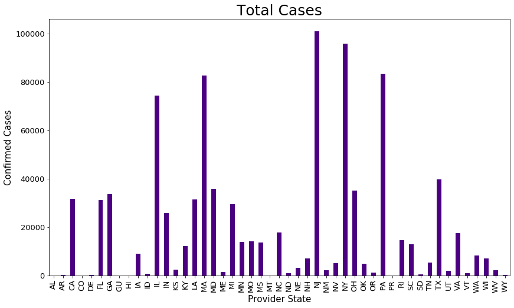

```python
plotdata('Provider State_x', 'Residents Total Confirmed COVID-19', 'Provider State', 'Total Cases', 'Confirmed Cases')
```

The below bar chart denotes the count of Total Deaths in every state of US

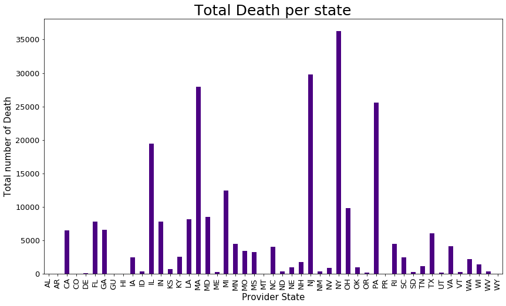

```python
plotdata('Provider State_x','Residents Total COVID-19 Deaths','Provider State','Total Death per state','Total number of Death')
```

Here i have calculated the count of Total Confirmed COVID-cases as per the Provider name, state and city as shown in the table below

```python
s=filtered_data.groupby(['Provider State_x','Provider City','Provider Name_x'],sort=True)['Residents Total Confirmed COVID-19'].sum().sort_values(ascending=False)
nursinghome_cases=pd.DataFrame(s).reset_index()
nursinghome_cases=pd.DataFrame(s.nlargest(10)).reset_index()
nursinghome_cases.columns=['Provider State_x','Provider City','Provider Name_x','Total Confirmed cases']
nursinghome_cases
```

|  | Provider State_x | Provider City | Provider Name_x | Total Confirmed cases |
| --- | --- | --- | --- | --- |
| 0 | NJ | NEWARK | NEW VISTA | 2490.0 |
| 1 | NJ | PARAMUS | BERGEN NEW BRIDGE MEDICAL CENTER | 2184.0 |
| 2 | PA | LIMA | FAIR ACRES GERIATRIC CENTER | 2053.0 |
| 3 | PA | HARRISBURG | SPRING CREEK REHABILITATION AND NURSING CENTER | 1898.0 |
| 4 | PA | ALLENTOWN | CEDARBROOK SENIOR CARE AND REHABILITATION | 1800.0 |
| 5 | NY | ORCHARD PARK | FATHER BAKER MANOR | 1703.0 |
| 6 | MD | CHARLOTTE HALL | CHARLOTTE HALL VETERANS HOME | 1697.0 |
| 7 | NY | SYRACUSE | BISHOP REHABILITATION AND NURSING CENTER | 1697.0 |
| 8 | VA | RICHMOND | CANTERBURY REHABILITATION & HEALTH CARE CENTER | 1620.0 |
| 9 | MA | MEDFORD | COURTYARD NURSING CARE CENTER | 1548.0 |